# Survey data analysis plan

Wesley

December 20, 2014

### View correlation matrix

```
##
## Two-Step Estimates
##
## Correlations/Type of Correlation:
##           Q1         Q2         Q3         Q4         Q5         Q6
## Q1         1 Polychoric Polychoric Polychoric Polychoric Polychoric
## Q2    0.9718          1 Polychoric Polychoric Polychoric Polychoric
## Q3    0.9903     0.9603          1 Polychoric Polychoric Polychoric
## Q4    0.1298     0.1241     0.1187          1 Polychoric Polychoric
## Q5    0.1246     0.1219     0.1234     0.9718          1 Polychoric
## Q6    0.1088    0.09793    0.09445     0.9818     0.9721          1
## Q7  -0.02047   -0.01205    -0.0737    -0.0657   -0.05737   -0.06761
## Q8 -0.009696   -0.02669   -0.02173  -0.002982   -0.01921  -0.009016
## Q9    0.0974     0.1449    0.09043    0.08454    0.06609    0.08656
##            Q7         Q8         Q9
## Q1 Polychoric Polychoric Polychoric
## Q2 Polychoric Polychoric Polychoric
## Q3 Polychoric Polychoric Polychoric
## Q4 Polychoric Polychoric Polychoric
## Q5 Polychoric Polychoric Polychoric
## Q6 Polychoric Polychoric Polychoric
## Q7          1 Polychoric Polychoric
## Q8  0.0006141          1 Polychoric
## Q9    -0.0186    0.04532          1
```

### Sample a training set (n=200)

### Step 1a. Generate items

- Create items (i.e. Questions) that supposedly tap into the target construct
- Questions should be as expansive as possible: maximize face value
- Redundancy at this stage is fine but missing items is serious

### Step 1b Screening items

Non-linear principal components analysis with Promax rotation is performed:

```
## Principal Components Analysis
## Call: principal(r = train.cor$correlations, nfactors = ncol(train) -
##     1, rotate = "promax")
## Standardized loadings (pattern matrix) based upon correlation matrix
##      PC1  PC2   PC3   PC5 PC4   PC6   PC7   PC8 h2      u2
## Q1  0.01 1.00  0.06 -0.03   0  0.00 -0.03 -0.02  1 1.6e-08
## Q2  0.00 0.95  0.00  0.00   0  0.25  0.00  0.00  1 6.1e-11
## Q3 -0.01 1.00 -0.06  0.03   0 -0.02  0.03  0.01  1 1.5e-08
## Q4  0.99 0.00  0.00  0.00   0  0.00 -0.01  0.10  1 8.9e-12
## Q5  0.98 0.00  0.02 -0.01   0  0.00  0.21  0.00  1 1.3e-09
## Q6  1.00 0.00 -0.02  0.01   0  0.00  0.00 -0.09  1 1.7e-09
## Q7  0.00 0.00  1.00  0.00   0  0.00  0.00  0.00  1 2.6e-10
## Q8  0.00 0.00  0.00  0.00   1  0.00  0.00  0.00  1 1.5e-12
## Q9  0.00 0.00  0.00  1.00   0  0.00  0.00  0.00  1 6.1e-11
##
##                        PC1  PC2  PC3  PC5  PC4  PC6  PC7  PC8
## SS loadings           2.95 2.90 1.01 1.00 1.00 0.08 0.04 0.02
## Proportion Var        0.33 0.32 0.11 0.11 0.11 0.01 0.00 0.00
## Cumulative Var        0.33 0.65 0.76 0.87 0.98 0.99 1.00 1.00
## Proportion Explained  0.33 0.32 0.11 0.11 0.11 0.01 0.00 0.00
## Cumulative Proportion 0.33 0.65 0.76 0.87 0.98 0.99 1.00 1.00
##
##  With component correlations of
##       PC1   PC2   PC3   PC5   PC4  PC6   PC7   PC8
## PC1  1.00  0.11  0.08  0.19 -0.05 0.24 -0.03  0.04
## PC2  0.11  1.00 -0.01  0.14 -0.16 0.08 -0.02  0.09
## PC3  0.08 -0.01  1.00 -0.10  0.04 0.29  0.02 -0.08
## PC5  0.19  0.14 -0.10  1.00 -0.01 0.04  0.04  0.21
## PC4 -0.05 -0.16  0.04 -0.01  1.00 0.02 -0.04 -0.04
## PC6  0.24  0.08  0.29  0.04  0.02 1.00  0.02  0.25
## PC7 -0.03 -0.02  0.02  0.04 -0.04 0.02  1.00  0.10
## PC8  0.04  0.09 -0.08  0.21 -0.04 0.25  0.10  1.00
##
## Test of the hypothesis that 8 components are sufficient.
##
## The degrees of freedom for the null model are  36  and the objective function was  25.97
## The degrees of freedom for the model are -8  and the objective function was  0.55
##
## Fit based upon off diagonal values = 1
```

### Step 1b Screening items (cont)

```r
train <- train[,-c(7:9)]
```

### Step 2. Exploratory Factor Analysis

1. Determine number of factors underlying the data
2. Identify which variables load on to which factors
3. Remove variables which do not load onto any factors

*New data should be used*, we use that data that was not used just now (n=300)

### Step 2. EFA: Parallel analysis

```
##
##
##
##  See the graphic output for a description of the results
```

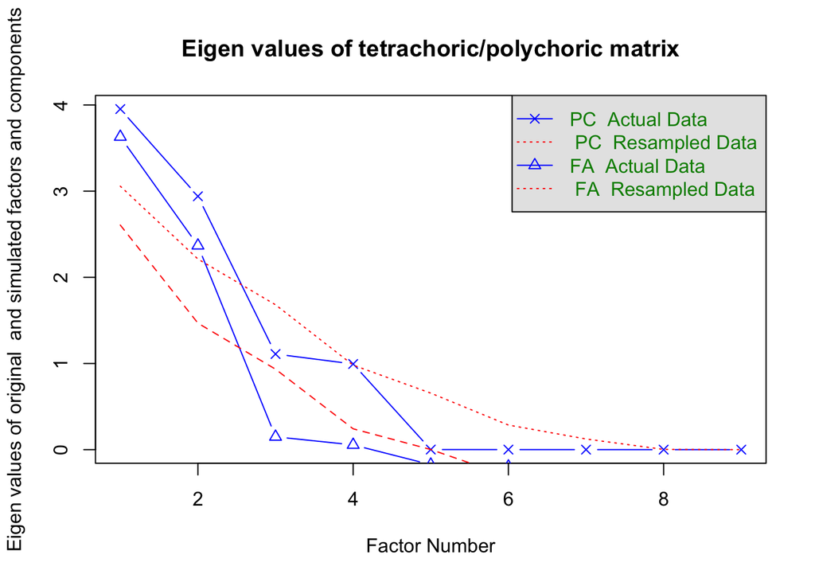

```
## Parallel analysis suggests that the number of factors =  2  and the number of components =  2
```

### Step 2. EFA: Parallel analysis (cont.)

1. artificial datasets is generated with the same number of variables and same number of observations
2. Variables in these datasets are random variables
3. Factor analysis is performed on each of these datasets and the eigenvalues of each factor generated are extracted
4. Repeating this many times will allow us to calculate the mean eigenvalue of a factor from datasets similar to what we have
5. An eigenvalue less than the mean would mean that a particular factor extracted is no more substantial (explains less) than a random factor (which really has no meaning); those factors are rejected

### Step 2. EFA: Parallel analysis (cont.)

Parallel analysis suggests **2 factors** are to be extracted

### Step 2. EFA: Factor analysis with the number of factors selected by PA

```
##
## Call:
## factanal(factors = test.parallel$nfact, covmat = test.cor$correlations)
##
## Uniquenesses:
##    Q1    Q2    Q3    Q4    Q5    Q6    Q7    Q8    Q9
## 0.005 0.048 0.015 0.021 0.036 0.019 0.971 0.992 0.993
##
## Loadings:
##    Factor1 Factor2
## Q1          0.994
## Q2          0.974
## Q3          0.989
## Q4  0.989
## Q5  0.980
## Q6  0.991
## Q7 -0.160
## Q8
## Q9
##
##                Factor1 Factor2
## SS loadings      2.962   2.938
## Proportion Var   0.329   0.326
## Cumulative Var   0.329   0.656
##
## The degrees of freedom for the model is 19 and the fit was 0.5698
```

### Step 2. EFA: Screening items

This step is identical to that performed during PCA

- We look for factors that load clearly onto one component
- Try to minimize cross-loading: i.e. high loadings on >1 component
- A cut-off that is generally accepted (but should be reported)
1. `>`0.50-0.60 on main factor and <0.20-0.30 on others
2. We can discard questions that don’t meet this criteria
- *Make sure that the results make theorectical sense!*

### Step 3. Regression based on factor scores